# Problem Statement

The aim is to build a predictive model and predict the sales of each product at a particular outlet. Using this model, BigMart will try to understand the properties of products and outlets which play a key role in increasing sales.

# Dataset Description

The dataset contains 8523 rows and 12 columns. Each row contains is a product and its description

```python
# Import the numpy and pandas libraries
import numpy as np
import pandas as pd

#Import visualisation library
import matplotlib.pyplot as plt
import seaborn as sns

#Import Statsmodel
import statsmodels
import statsmodels.formula.api as smf

# Using scikit-learn
from sklearn.preprocessing import LabelEncoder
from sklearn.model_selection import train_test_split
from sklearn.linear_model import LinearRegression
from sklearn import metrics
from sklearn.preprocessing import StandardScaler
from sklearn.linear_model import Ridge, RidgeCV, Lasso
from sklearn.model_selection import KFold, cross_val_score
import sklearn.metrics as metrics
from math import sqrt
from sklearn import linear_model
from sklearn.ensemble import RandomForestRegressor
from sklearn.metrics import r2_score,mean_absolute_error,mean_squared_error
from sklearn.tree import DecisionTreeRegressor
from sklearn.neighbors import KNeighborsRegressor as KNR


#Import Metrics
from statsmodels.tools.eval_measures import rmse

# Import
import scipy.stats as stats
import pylab

# Import warnings
import warnings

#Notebook Configurations
%matplotlib inline
sns.set(color_codes=True)
warnings.filterwarnings('ignore')
```

```python
train= pd.read_csv("Train.csv")
test=pd.read_csv('Test_bigmart.csv')
```

```python
train.head()
```

|  | Item_Identifier | Item_Weight | Item_Fat_Content | Item_Visibility | Item_Type | Item_MRP | Outlet_Identifier | Outlet_Establishment_Year | Outlet_Size | Outlet_Location_Type | Outlet_Type | Item_Outlet_Sales |
| --- | --- | --- | --- | --- | --- | --- | --- | --- | --- | --- | --- | --- |
| 0 | FDA15 | 9.30 | Low Fat | 0.016047 | Dairy | 249.8092 | OUT049 | 1999 | Medium | Tier 1 | Supermarket Type1 | 3735.1380 |
| 1 | DRC01 | 5.92 | Regular | 0.019278 | Soft Drinks | 48.2692 | OUT018 | 2009 | Medium | Tier 3 | Supermarket Type2 | 443.4228 |
| 2 | FDN15 | 17.50 | Low Fat | 0.016760 | Meat | 141.6180 | OUT049 | 1999 | Medium | Tier 1 | Supermarket Type1 | 2097.2700 |
| 3 | FDX07 | 19.20 | Regular | 0.000000 | Fruits and Vegetables | 182.0950 | OUT010 | 1998 | NaN | Tier 3 | Grocery Store | 732.3800 |
| 4 | NCD19 | 8.93 | Low Fat | 0.000000 | Household | 53.8614 | OUT013 | 1987 | High | Tier 3 | Supermarket Type1 | 994.7052 |

```python
# Checking the columns with null values
train.info()
```

```
<class 'pandas.core.frame.DataFrame'>
RangeIndex: 8523 entries, 0 to 8522
Data columns (total 12 columns):
 #   Column                     Non-Null Count  Dtype
---  ------                     --------------  -----
 0   Item_Identifier            8523 non-null   object
 1   Item_Weight                7060 non-null   float64
 2   Item_Fat_Content           8523 non-null   object
 3   Item_Visibility            8523 non-null   float64
 4   Item_Type                  8523 non-null   object
 5   Item_MRP                   8523 non-null   float64
 6   Outlet_Identifier          8523 non-null   object
 7   Outlet_Establishment_Year  8523 non-null   int64
 8   Outlet_Size                6113 non-null   object
 9   Outlet_Location_Type       8523 non-null   object
 10  Outlet_Type                8523 non-null   object
 11  Item_Outlet_Sales          8523 non-null   float64
dtypes: float64(4), int64(1), object(7)
memory usage: 799.2+ KB
```

```python
train.isnull().sum()
```

```
Item_Identifier                 0
Item_Weight                  1463
Item_Fat_Content                0
Item_Visibility                 0
Item_Type                       0
Item_MRP                        0
Outlet_Identifier               0
Outlet_Establishment_Year       0
Outlet_Size                  2410
Outlet_Location_Type            0
Outlet_Type                     0
Item_Outlet_Sales               0
dtype: int64
```

```python
test.info()
```

```
<class 'pandas.core.frame.DataFrame'>
RangeIndex: 5681 entries, 0 to 5680
Data columns (total 11 columns):
 #   Column                     Non-Null Count  Dtype
---  ------                     --------------  -----
 0   Item_Identifier            5681 non-null   object
 1   Item_Weight                4705 non-null   float64
 2   Item_Fat_Content           5681 non-null   object
 3   Item_Visibility            5681 non-null   float64
 4   Item_Type                  5681 non-null   object
 5   Item_MRP                   5681 non-null   float64
 6   Outlet_Identifier          5681 non-null   object
 7   Outlet_Establishment_Year  5681 non-null   int64
 8   Outlet_Size                4075 non-null   object
 9   Outlet_Location_Type       5681 non-null   object
 10  Outlet_Type                5681 non-null   object
dtypes: float64(3), int64(1), object(7)
memory usage: 488.3+ KB
```

# Data Cleaning

```python
#font dictionary
font={'family': 'serif', 'weight':'normal' ,'color':'black', 'size': 16}
```

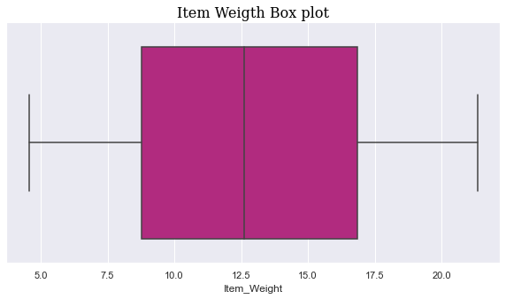

```python
# Plot boxplot to check for outliers in the data
plt.figure(figsize=(10,5))
sns.boxplot(train.Item_Weight, color='#C71585')
plt.title("Item Weigth Box plot", font)
plt.show()
```

```python
# Fill in the missing values for Item Weight with the median
Item_Weight_mean=train.Item_Weight.mean()
train.Item_Weight.fillna(Item_Weight_mean, inplace=True)
```

```python
# Fill in the missing values for Item Weight with the median
Item_Weight_mean=test.Item_Weight.mean()
test.Item_Weight.fillna(Item_Weight_mean, inplace=True)
```

```python
train.Item_Weight.isnull().sum()
```

```
0
```

```python
test.Item_Weight.isnull().sum()
```

```
0
```

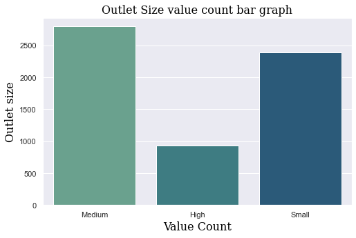

```python
plt.figure(figsize=(8,5))
sns.countplot('Outlet_Size', data=train, palette='crest')
plt.title("Outlet Size value count bar graph", font)
plt.ylabel('Outlet size', font)
plt.xlabel('Value Count', font)
plt.figure(figsize=(8,5))
plt.show()
```

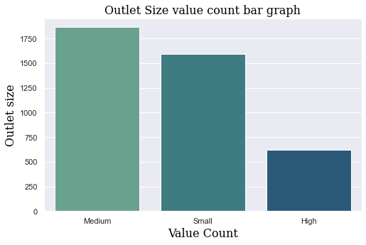

```python
plt.figure(figsize=(8,5))
sns.countplot('Outlet_Size', data=test, palette='crest')
plt.title("Outlet Size value count bar graph", font)
plt.ylabel('Outlet size', font)
plt.xlabel('Value Count', font)
plt.figure(figsize=(8,5))
plt.show()
```

```python
# Fill in the missing values for outlet size with the mode
train.Outlet_Size.fillna('Medium', inplace=True)
train.Outlet_Size.value_counts()
```

```
Medium    5203
Small     2388
High       932
Name: Outlet_Size, dtype: int64
```

```python
# Fill in the missing values for outlet size with the mode
test.Outlet_Size.fillna('Medium', inplace=True)
test.Outlet_Size.value_counts()
```

```
Medium    3468
Small     1592
High       621
Name: Outlet_Size, dtype: int64
```

```python
train.Outlet_Size.isnull().sum()
```

```
0
```

```python
train.Item_Fat_Content.unique()
```

```
array(['Low Fat', 'Regular', 'low fat', 'LF', 'reg'], dtype=object)
```

```python
test.Item_Fat_Content.unique()
```

```
array(['Low Fat', 'reg', 'Regular', 'LF', 'low fat'], dtype=object)
```

```python
train.Item_Fat_Content.replace(['low fat','LF','reg'],['Low Fat', 'Low Fat', 'Regular'], inplace = True)
```

```python
test.Item_Fat_Content.replace(['low fat','LF','reg'],['Low Fat', 'Low Fat', 'Regular'], inplace = True)
```

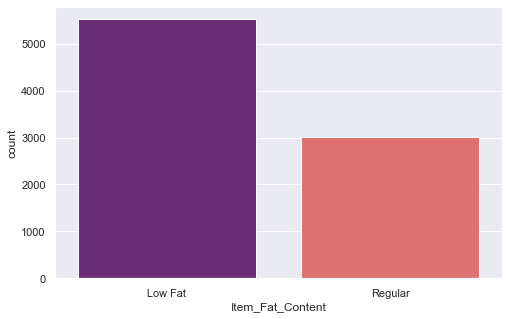

```python
plt.figure(figsize=(8,5))
sns.countplot('Item_Fat_Content', data=train, palette='magma')
sns.set(font_scale=1)
plt.show()
```

# Data Exploration

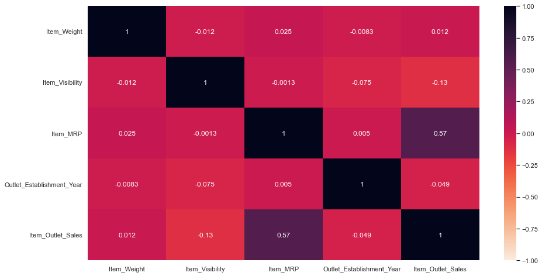

```python
# Heatmap to show correlation between variables
plt.figure(figsize = (15,8))
sns.heatmap(train.corr(), vmin=-1, vmax=1,
annot=True,cmap="rocket_r")
sns.set(font_scale=1)
plt.show()
```

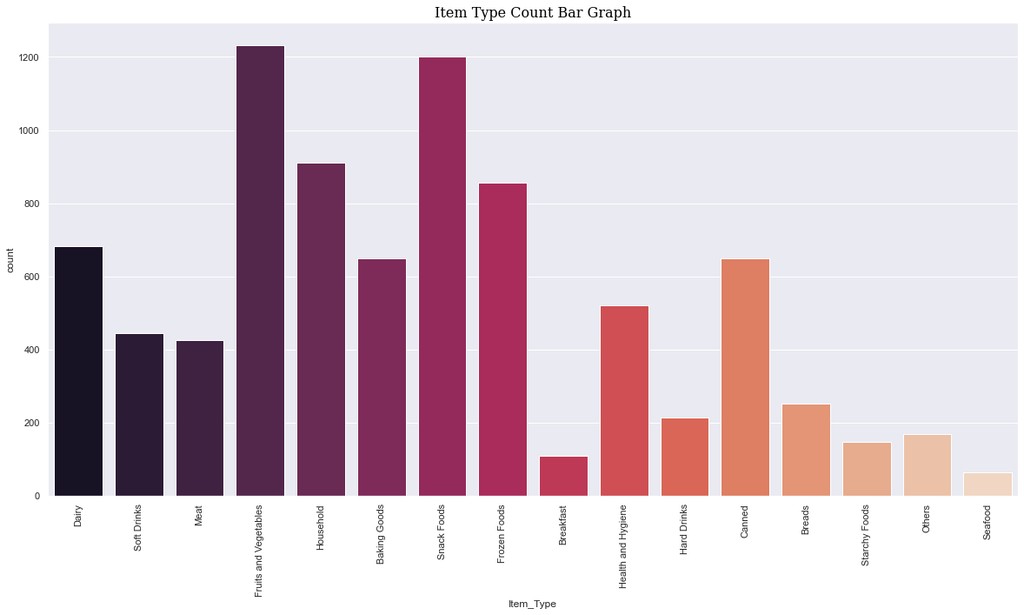

```python
plt.figure(figsize=(20,10))
sns.countplot('Item_Type', data=train, palette='rocket')
sns.set(font_scale=1)
plt.title("Item Type Count Bar Graph", font)
plt.xticks(rotation=90)
plt.show()
```

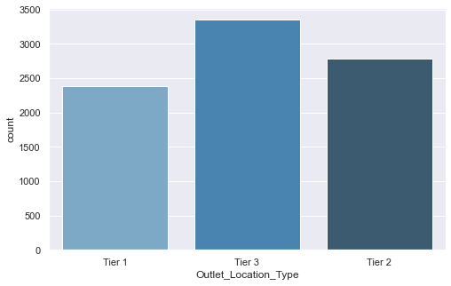

```python
plt.figure(figsize=(8,5))
sns.countplot('Outlet_Location_Type', data=train, palette='Blues_d')
```

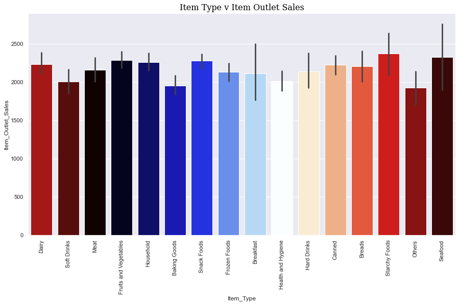

```python
plt.figure(figsize=(15,8))
sns.barplot(x='Item_Type', y='Item_Outlet_Sales', data=train, palette= 'flag')
plt.title('Item Type v Item Outlet Sales', font)
plt.xticks(rotation=90)
plt.show()
```

Observations: The products available were Fruits-Veggies and Snack Foods but the sales of Seafood and Starchy Foods seems higher and hence the sales can be improved with having stock of products that are most bought by customers.

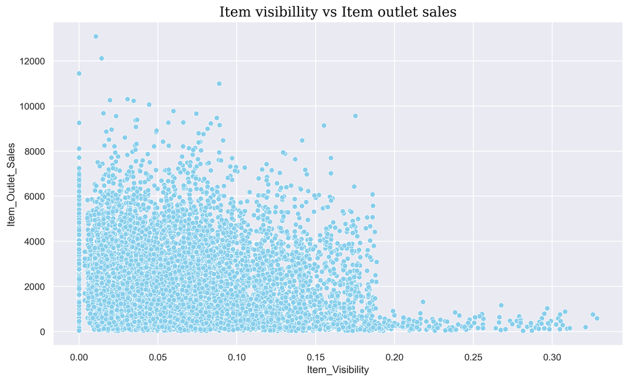

```python
#Scatter plot Item visibillity vs Item outlet sales
plt.figure(figsize=(12,7), dpi=300)
sns.scatterplot(x="Item_Visibility", y="Item_Outlet_Sales", data=train, color='skyblue')
sns.set(font_scale=1)
plt.title("Item visibillity vs Item outlet sales", font)
plt.show()
```

Items having the most sales have visibillity less than 0.2

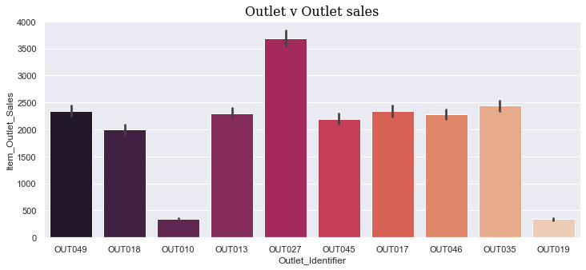

```python
fig, ax = plt.subplots(figsize=(12,5))
sns.barplot(x='Outlet_Identifier', y='Item_Outlet_Sales', data=train, palette='rocket')
plt.title('Outlet v Outlet sales', font)
plt.show()
```

# OUT027 has contributed to majority of sales followed by OUT35. OUT10 and OUT19 have probably the least thereby contributing to the least outlet sales.

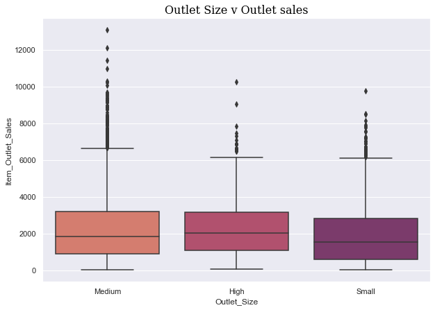

```python
plt.figure(figsize=(10,7))
sns.boxplot(x = 'Outlet_Size', y = 'Item_Outlet_Sales', data=train, palette='flare')
plt.title('Outlet Size v Outlet sales', font)
plt.show()
```

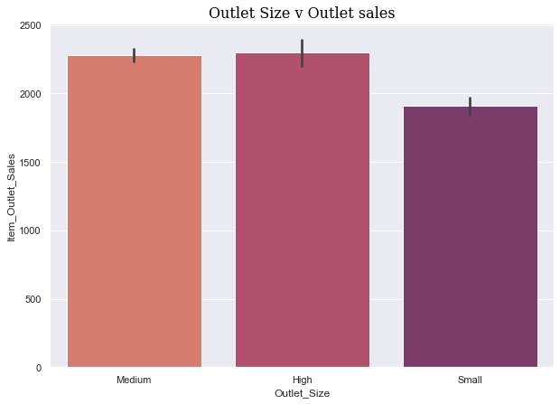

```python
plt.figure(figsize=(10,7))
sns.barplot(x = 'Outlet_Size', y = 'Item_Outlet_Sales', data=train, palette='flare')
plt.title('Outlet Size v Outlet sales', font)
plt.show()
```

Observations: The Outlet Sales is maximum for Medium and High sized Outlets. The Outlets we have is Medium and may be with High size Outlets can improve the Outlet Sales.

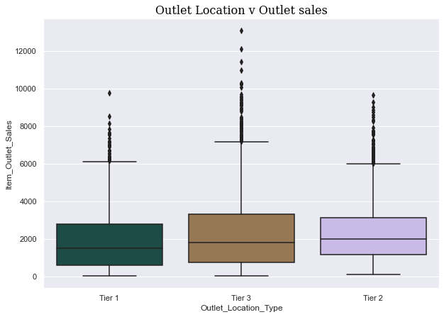

```python
plt.figure(figsize=(10,7))
sns.boxplot(x = 'Outlet_Location_Type', y = 'Item_Outlet_Sales', data=train, palette="cubehelix")
plt.title('Outlet Location v Outlet sales', font)
plt.show()
```

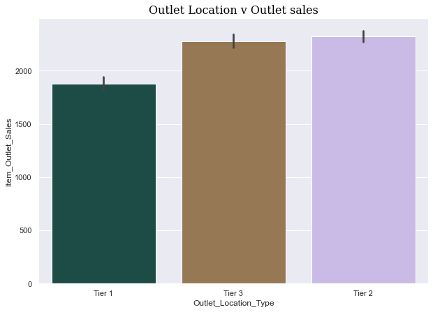

```python
plt.figure(figsize=(10,7))
sns.barplot(x = 'Outlet_Location_Type', y = 'Item_Outlet_Sales', data=train, palette="cubehelix")
plt.title('Outlet Location v Outlet sales', font)
plt.show()
```

Observations: The Outlet Sales tend to be high for Tier3 and Tier 2 location types but we have only Tier3 locations maximum Outlets

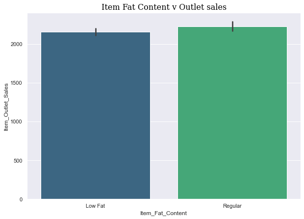

```python
plt.figure(figsize=(10,7))
sns.barplot(x = 'Item_Fat_Content', y = 'Item_Outlet_Sales', data=train, palette='viridis')
plt.title('Item Fat Content v Outlet sales', font)
plt.show()
```

Observation:The Item Outles sales are high for both Low Fat and Regular Item types.

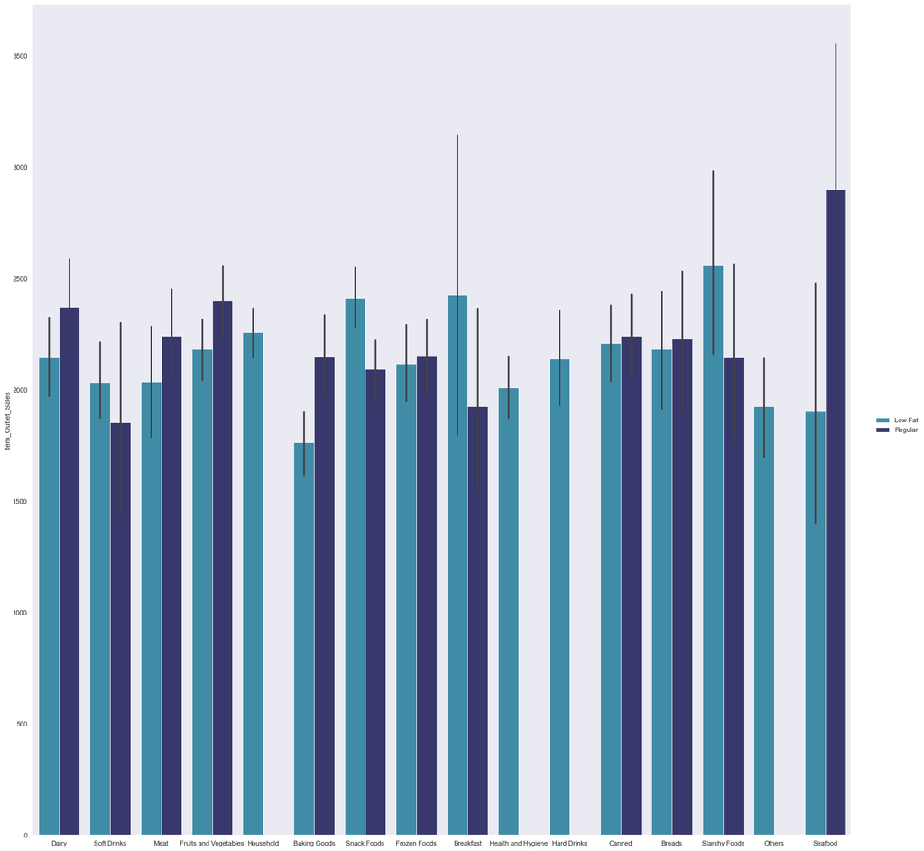

```python
sns.set_theme(style="dark")
g = sns.catplot(
    data=train, kind="bar",
    x="Item_Type", y="Item_Outlet_Sales", hue="Item_Fat_Content",
     palette="ocean_r", alpha=.8, height=20
)
g.despine(left=True)
g.set_axis_labels("", "Item_Outlet_Sales")
g.legend.set_title("")
```

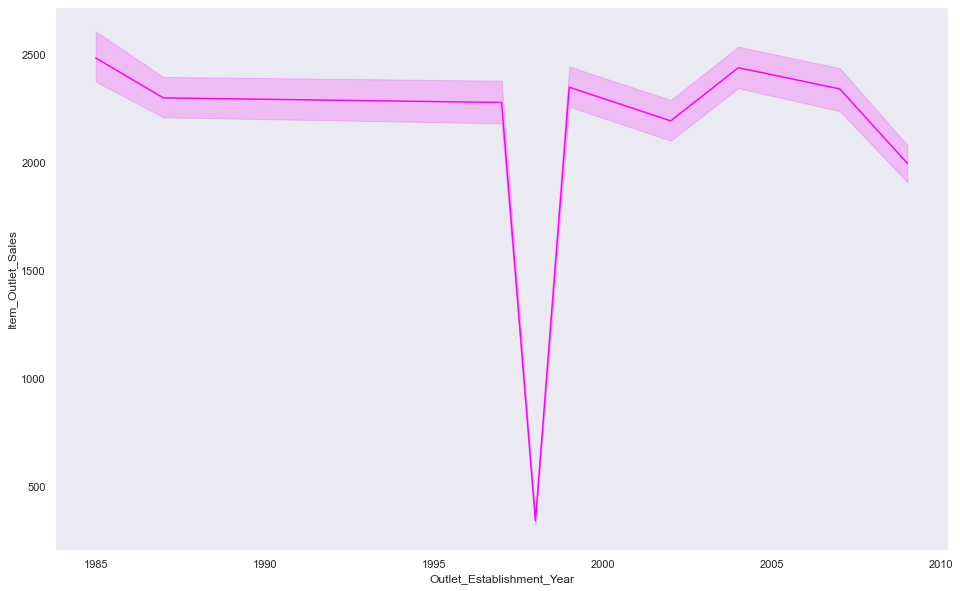

```python
plt.figure(figsize = (16,10))
sns.lineplot(x = 'Outlet_Establishment_Year', y = 'Item_Outlet_Sales', data = train, color="magenta" )
plt.show()
```

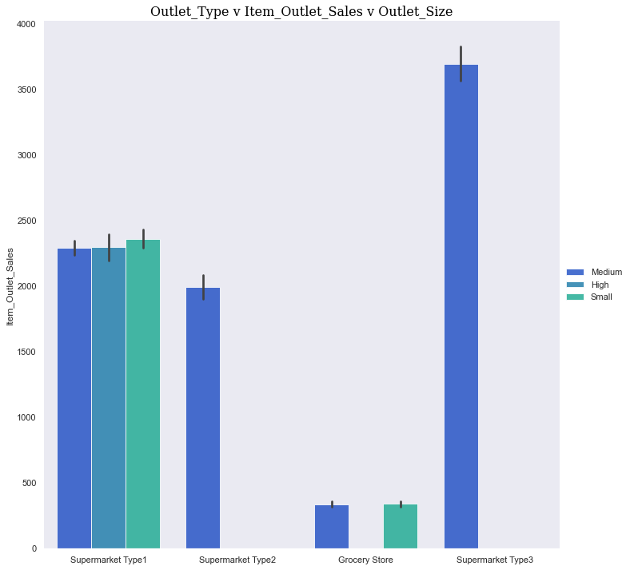

```python
g = sns.catplot(
    data=train, kind="bar",
    x="Outlet_Type", y="Item_Outlet_Sales", hue="Outlet_Size",
     palette="winter", alpha=.8, height=10
)
g.despine(left=True)
g.set_axis_labels("", "Item_Outlet_Sales")
g.legend.set_title("")
plt.title("Outlet_Type v Item_Outlet_Sales v Outlet_Size", font)
plt.show()
```

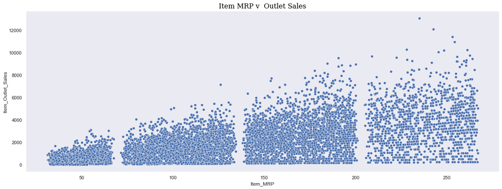

```python
plt.figure(figsize =(20,7))
sns.scatterplot(x = 'Item_MRP',y = 'Item_Outlet_Sales',data = train)
plt.title("Item MRP v  Outlet Sales", font)
plt.show()
```

# Feature Engineering

```python
#Item_Identifier, Outlet_Identifier and Outlet_Establishment_Year are supposed to be dropped as they don't seem to be helping in our analysis.
train.drop(columns = ['Item_Identifier','Outlet_Identifier','Outlet_Establishment_Year'], axis = 1, inplace = True)
test.drop(columns = ['Item_Identifier','Outlet_Identifier','Outlet_Establishment_Year'], axis = 1, inplace = True)
```

```python
train.shape, test.shape
```

```
((8523, 9), (5681, 8))
```

# Label Encoding

```python
encoder = LabelEncoder()
```

```python
elements = train.select_dtypes(include=['object']).columns
```

```python
elements
```

```
Index(['Item_Fat_Content', 'Item_Type', 'Outlet_Size', 'Outlet_Location_Type',
       'Outlet_Type'],
      dtype='object')
```

```python
for i in elements:
    train[i] = encoder.fit_transform(train[i])

for elements in test:
    test[i] = encoder.fit_transform(test[i])
```

```python
train.info()
```

```
<class 'pandas.core.frame.DataFrame'>
RangeIndex: 8523 entries, 0 to 8522
Data columns (total 9 columns):
 #   Column                Non-Null Count  Dtype
---  ------                --------------  -----
 0   Item_Weight           8523 non-null   float64
 1   Item_Fat_Content      8523 non-null   int32
 2   Item_Visibility       8523 non-null   float64
 3   Item_Type             8523 non-null   int32
 4   Item_MRP              8523 non-null   float64
 5   Outlet_Size           8523 non-null   int32
 6   Outlet_Location_Type  8523 non-null   int32
 7   Outlet_Type           8523 non-null   int32
 8   Item_Outlet_Sales     8523 non-null   float64
dtypes: float64(4), int32(5)
memory usage: 432.9 KB
```

```python
test.info()
```

```
<class 'pandas.core.frame.DataFrame'>
RangeIndex: 5681 entries, 0 to 5680
Data columns (total 8 columns):
 #   Column                Non-Null Count  Dtype
---  ------                --------------  -----
 0   Item_Weight           5681 non-null   float64
 1   Item_Fat_Content      5681 non-null   object
 2   Item_Visibility       5681 non-null   float64
 3   Item_Type             5681 non-null   object
 4   Item_MRP              5681 non-null   float64
 5   Outlet_Size           5681 non-null   object
 6   Outlet_Location_Type  5681 non-null   object
 7   Outlet_Type           5681 non-null   int64
dtypes: float64(3), int64(1), object(4)
memory usage: 355.2+ KB
```

# Definig X and Y

```python
X = train.drop(['Item_Outlet_Sales'], axis = 1)
X.head()
```

|  | Item_Weight | Item_Fat_Content | Item_Visibility | Item_Type | Item_MRP | Outlet_Size | Outlet_Location_Type | Outlet_Type |
| --- | --- | --- | --- | --- | --- | --- | --- | --- |
| 0 | 9.30 | 0 | 0.016047 | 4 | 249.8092 | 1 | 0 | 1 |
| 1 | 5.92 | 1 | 0.019278 | 14 | 48.2692 | 1 | 2 | 2 |
| 2 | 17.50 | 0 | 0.016760 | 10 | 141.6180 | 1 | 0 | 1 |
| 3 | 19.20 | 1 | 0.000000 | 6 | 182.0950 | 1 | 2 | 0 |
| 4 | 8.93 | 0 | 0.000000 | 9 | 53.8614 | 0 | 2 | 1 |

```python
y = train['Item_Outlet_Sales']
y.head()
```

```
0    3735.1380
1     443.4228
2    2097.2700
3     732.3800
4     994.7052
Name: Item_Outlet_Sales, dtype: float64
```

```python
X_train, X_test, y_train, y_test = train_test_split(X, y, test_size  = 0.2, random_state = 42 )
```

```python
print(X.shape, X_train.shape, X_test.shape)
```

```
(8523, 8) (6818, 8) (1705, 8)
```

```python
X.columns
```

```
Index(['Item_Weight', 'Item_Fat_Content', 'Item_Visibility', 'Item_Type',
       'Item_MRP', 'Outlet_Size', 'Outlet_Location_Type', 'Outlet_Type'],
      dtype='object')
```

```python
features = ['Item_Weight', 'Item_Fat_Content', 'Item_Visibility', 'Item_Type',
       'Item_MRP', 'Outlet_Size', 'Outlet_Location_Type', 'Outlet_Type']
```

# 1) Linear Regression

```python
LR = LinearRegression(normalize=True)
LR.fit(X_train,y_train)
y_pred = LR.predict(X_test)
coef2 = pd.Series(LR.coef_,features).sort_values()
```

```python
coef2
```

```
Item_Visibility        -1669.169718
Outlet_Location_Type    -424.353533
Outlet_Size             -351.068590
Item_Weight               -2.678645
Item_Type                  0.235213
Item_MRP                  15.629847
Item_Fat_Content          66.230487
Outlet_Type              989.839428
dtype: float64
```

```python
r2_Linear_Regression = r2_score(y_test, y_pred)
print('R2 score of Linear regression:',r2_Linear_Regression)
```

```
R2 score of Linear regression: 0.5240492826918414
```

```python
MAE = metrics.mean_absolute_error(y_test, y_pred)
MSE = metrics.mean_squared_error(y_test, y_pred)
rmse = sqrt(MSE)
```

```python
print("mean absolute error:",MAE)
print("mean squared error:",MSE)
print("Root Mean Squared Error:",rmse)
```

```
mean absolute error: 856.1001290020914
mean squared error: 1293619.8028283326
Root Mean Squared Error: 1137.3740821859503
```

# 2) Random Forest Regressor

```python
def result(y_test,y_pred):
    print(f"MAE : {mean_absolute_error(y_test, y_pred)}")
    print(f"MSE : {mean_squared_error(y_test, y_pred)}")
    print(f"RMSE : {np.sqrt(mean_squared_error(y_test, y_pred))}")
```

```python
RF = RandomForestRegressor(n_estimators=200,max_depth=5, min_samples_leaf=100,n_jobs=4,random_state=22)
```

```python
# Fitting the model on our trained dataset.
RF.fit(X_train,y_train)

# Making Predictions
y_pred = RF.predict(X_test)
```

```python
# Random Forest Regressor
result(y_test, y_pred)
feature_scores = pd.Series(RF.feature_importances_, index=X_train.columns).sort_values(ascending=False)
feature_scores.head(5)
```

```
MAE : 716.340467820868
MSE : 1036205.2305991129
RMSE : 1017.9416636522512
```

```
Item_MRP                0.553923
Outlet_Type             0.444729
Item_Weight             0.000555
Item_Visibility         0.000442
Outlet_Location_Type    0.000210
dtype: float64
```

# 3)Lasso

```python
LS = Lasso(alpha=10)
#fit
LS.fit(X_train,y_train)

#predict

y_predict = LS.predict(X_test)
```

```python
#score variables
LS_MAE = metrics.mean_absolute_error(y_test, y_predict)
LS_MSE = metrics.mean_squared_error(y_test, y_predict)
LS_rmse = sqrt(LS_MSE)
```

```python
print("mean absolute error:",LS_MAE)
print("mean squared error:",LS_MSE)
print("Root Mean Squared Error:",LS_rmse)
```

```
mean absolute error: 854.7188900390847
mean squared error: 1292770.3744829139
Root Mean Squared Error: 1137.0006044338384
```

# 4) Ridge Regression

```python
RR = Ridge(alpha=5)
#fit
RR.fit(X_train,y_train)

#predict

y_predicts = RR.predict(X_test)
```

```python
#score variables
RR_MAE = metrics.mean_absolute_error(y_test, y_predicts)
RR_MSE = metrics.mean_squared_error(y_test, y_predicts)
RR_rmse = sqrt(RR_MSE)
```

```python
print("mean absolute error:",RR_MAE)
print("mean squared error:",RR_MSE)
print("Root Mean Squared Error:",RR_rmse)
```

```
mean absolute error: 855.3075437458826
mean squared error: 1292411.7930496233
Root Mean Squared Error: 1136.8429060558997
```

# 5) DecisionTreeRegressor

```python
dt = DecisionTreeRegressor(max_depth=5,random_state=42)
dt.fit(X_train, y_train)
y_pred = dt.predict(X_test)
```

```python
result(y_test, y_pred)
feature_scores = pd.Series(dt.feature_importances_, index=X_train.columns).sort_values(ascending=False)
feature_scores.head(5)
```

```
MAE : 722.1698517497831
MSE : 1056342.3614713373
RMSE : 1027.7851728213136
```

```
Item_MRP            0.551582
Outlet_Type         0.447348
Item_Visibility     0.000990
Item_Fat_Content    0.000049
Item_Type           0.000023
dtype: float64
```

# 6) K-Nearest Neighbors

```python
rmse_val_list = [] #to store rmse values for different k

for i in range(1,round(sqrt(X_train.shape[0]))):
    model = KNR(n_neighbors = i)

    model.fit(X_train, y_train)  #fit the model
    y_pred = model.predict(X_test) #make prediction on test set
    error = sqrt(mean_squared_error(y_test, y_pred)) #calculate rmse
    #print('RMSE value for k= ' , i , 'is:', error)

    rmse_val_list.append(error) #store rmse values

print("The minimum error we get is ", min(rmse_val_list))
print("The corresponding K value is ", 1+rmse_val_list.index(min(rmse_val_list)))
```

```
The minimum error we get is  1283.4264940030494
The corresponding K value is  24
```

# Random Forest Regressor, is the best model to use since it has the lowest Root squared mean error

# Item MRP the sales maximizes the Outlet sales.

Outlet Type being SuperMarket or Grocery Store also depicts the Outlet Sales.